# Discussion 4

## Data

You need the following datasets for this discussion (found on canvas). - atlanta.tsv - chicago.csv

## Questions

### 1

Using the Atlanta data set, complete the chunk below to do the following:

1. Select only the `airport`, `date`, `all_total`, and `all_flights` columns,
2. Parse the `date` column into a date format,
3. Rename the `all_total` and `all_flights` columns as `passengers` and `flights`,
4. Compute total passengers and flights counts for each date at each airport,
5. Add columns `wday` and `month` to indicate the weekday and month each date corresponds to. Make sure to use `label=TRUE` to get a name output,
6. And finally, sort the data frame by date from earliest to latest.

```r
# reads in the Atlanta tsv file
atl = read_tsv("../../data/atlanta-2018.tsv") %>% ...? #complete this line
```

```
## Error: <text>:4:0: unexpected end of input
## 2: atl = read_tsv("../../data/atlanta-2018.tsv") %>% ...? #complete this line
## 3:
##   ^
```

#### Solution

```r
## Solution
### Input a file where the delimiter character is a (a) TAB
atl = read_tsv("../../data/atlanta-2018.tsv") %>%
  select(airport,date,all_total,all_flights) %>%
  rename(passengers = all_total,
         flights = all_flights) %>%
  group_by(airport,date) %>%
  summarize(passengers = sum(passengers),
            flights = sum(flights)) %>%
  mutate(date = mdy(date),
         wday = wday(date, label=TRUE),
         month = month(date, label=TRUE)) %>%
  arrange(date)

atl
```

```
## # A tibble: 364 × 6
## # Groups:   airport [1]
##    airport date       passengers flights wday  month
##    <chr>   <date>          <dbl>   <dbl> <ord> <ord>
##  1 ATL     2018-01-01      15448      92 Mon   Jan
##  2 ATL     2018-01-02      18207     102 Tue   Jan
##  3 ATL     2018-01-03      17757     100 Wed   Jan
##  4 ATL     2018-01-04      18782     104 Thu   Jan
##  5 ATL     2018-01-05      18221     101 Fri   Jan
##  6 ATL     2018-01-06      20805     114 Sat   Jan
##  7 ATL     2018-01-07      17790      97 Sun   Jan
##  8 ATL     2018-01-08      16427      97 Mon   Jan
##  9 ATL     2018-01-09      15987      88 Tue   Jan
## 10 ATL     2018-01-10      15384      87 Wed   Jan
## # … with 354 more rows
```

### 2

Now, do the following:

- Create a summary data frame named `atl_sum` with columns for the average number of international flight arrivals per day and the average number of daily passengers arriving on international flights per day in Atlanta by day of the week.
- This data frame will have three columns, one for day of the week, and one for each of the two quantitative variables.
- Print out the summary data frame in a table with the rows arranged in order by days of the week from Sunday through Saturday.
- Also, print out the summary data frame in a table with the rows arranged in order from most to least average number of international flight arrivals.

*Note: You should have two summary data frames print, each arranged in a different order according to the directions above.*

#### Solution

```r
## Solution
atl_sum = atl %>%
  group_by(wday) %>%
  summarize(passengers = mean(passengers),
            flights = mean(flights))
atl_sum
```

```
## # A tibble: 7 × 3
##   wday  passengers flights
##   <ord>      <dbl>   <dbl>
## 1 Sun       16464.    90.4
## 2 Mon       15053.    84.8
## 3 Tue       14136     82.5
## 4 Wed       13785.    82.2
## 5 Thu       13983.    84.4
## 6 Fri       14778.    84.9
## 7 Sat       17828.   101.
```

```r
atl_sum %>%
  arrange(desc(flights))
```

```
## # A tibble: 7 × 3
##   wday  passengers flights
##   <ord>      <dbl>   <dbl>
## 1 Sat       17828.   101.
## 2 Sun       16464.    90.4
## 3 Fri       14778.    84.9
## 4 Mon       15053.    84.8
## 5 Thu       13983.    84.4
## 6 Tue       14136     82.5
## 7 Wed       13785.    82.2
```

### 3

> On what single date in April of 2018 did the largest number of international passengers arrive at the Atlanta airport? How many passengers were there? What day of the week was this date?

#### Solution

```r
## Solution
atl %>%
  filter(month == "Apr") %>%
  slice_max(passengers, n = 1)
```

```
## # A tibble: 1 × 6
## # Groups:   airport [1]
##   airport date       passengers flights wday  month
##   <chr>   <date>          <dbl>   <dbl> <ord> <ord>
## 1 ATL     2018-04-28      18481     103 Sat   Apr
```

ANSWER:

- April 28, 2018
- 18,481 passengers
- It was a Saturday

### 4

> Read in the data for Chicago using the appropriate `read_*()` command. (Each row in the data file represents an hour of a day. You will need to transform the data to obtain the values to graph. Borrow code from problem 1 to help.)
- Make a bar plot that shows the mean number of passengers arriving per day to O’Hare international airport by day of the week.

#### Solution

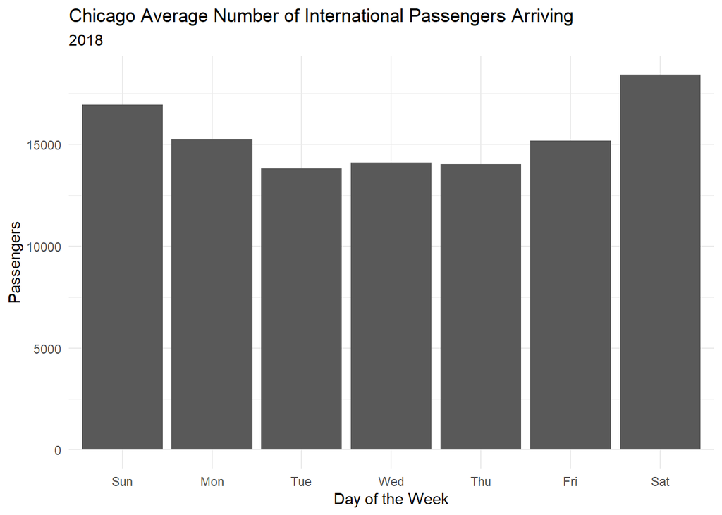

```r
## Solution
ord = read_csv2("../../data/chicago-2018.csv") %>%
  rename(passengers = all_total,
         flights = all_flights) %>%
  group_by(airport,date) %>%
  summarize(passengers = sum(passengers),
            flights = sum(flights)) %>%
  mutate(date = mdy(date)) %>%
  mutate(wday = wday(date, label=TRUE))

ord_sum = ord %>%
  group_by(wday) %>%
  summarize(passengers = mean(passengers))

ggplot(ord_sum, aes(x=wday, y = passengers)) +
  geom_col() +
  xlab("Day of the Week") +
  ylab("Passengers") +
  ggtitle("Chicago Average Number of International Passengers Arriving",
          subtitle = 2018) +
  theme_minimal()
```

### 5

> Using the Chicago data, make a line plot that shows the total number of international flights arriving to the airport by month. (Note: add `group = 1` as an aesthetic so that there is a single line for all months.)

#### Solution

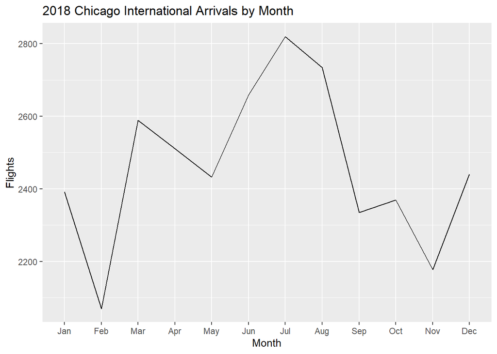

```r
## Solution
ord2 = read_csv2("../../data/chicago-2018.csv") %>%
  rename(passengers = all_total,
         flights = all_flights) %>%
  group_by(airport,date) %>%
  summarize(passengers = sum(passengers),
            flights = sum(flights)) %>%
  mutate(date = mdy(date)) %>%
  mutate(month = month(date, label=TRUE))

ord_sum2 = ord2 %>%
  group_by(month) %>%
  summarize(flights = sum(flights))

ggplot(ord_sum2, aes(x = month, y = flights, group = 1)) +
  geom_line() +
  xlab("Month") +
  ylab("Flights") +
  ggtitle("2018 Chicago International Arrivals by Month")
```